# Intro to R: Part 4

Basic probabilities and statistics

Author

Rubén Coca

```r
library(data.table)
library(tidyverse)
library(gtools)
library(corrplot)
library(pROC)
library(tigerstats)
# options(scipen = 10000)
```

### Intro

As we discussed in the first session, R was developed for “statistical computing and graphics”, so it provides a bunch of functions for working with statistical and probability problems[^1].

### Basic functions

Mean, median, quantiles, etc. are easily computed:

```r
data <- c(rep(c(1, 2, 3), 2), seq(6, 10), seq(from = 9, to = 7, by = -0.1))
```

```r
summary(data)
```

```
   Min. 1st Qu.  Median    Mean 3rd Qu.    Max.
  1.000   7.000   7.750   6.875   8.425  10.000
```

```r
mean(data)
```

```
[1] 6.875
```

```r
median(data)
```

```
[1] 7.75
```

```r
var(data)
```

```
[1] 6.36129
```

```r
sd(data)
```

```
[1] 2.52216
```

```r
quantile(data)
```

```
    0%    25%    50%    75%   100%
 1.000  7.000  7.750  8.425 10.000
```

```r
quantile(data, probs = 0.66)
```

```
  66%
8.146
```

```r
scale(data)
```

```
             [,1]
 [1,] -2.32935275
 [2,] -1.93286718
 [3,] -1.53638160
 [4,] -2.32935275
 [5,] -1.93286718
 [6,] -1.53638160
 [7,] -0.34692488
 [8,]  0.04956070
 [9,]  0.44604627
[10,]  0.84253185
[11,]  1.23901742
[12,]  0.84253185
[13,]  0.80288329
[14,]  0.76323473
```

[output cut: 22 more lines]

### Probability distributions

R provides functions to simulate many probability distributions (binomial, normal, uniform, beta, Poisson, etc.).

Every distribution that R handles has four functions. There is a root name, for example, the root name for the normal distribution is `norm`. This root is prefixed by one of the letters:

- `p` for “probability”, the cumulative distribution function (c. d. f.)
- `q` for “quantile”, the inverse c. d. f.
- `d` for “density”, the density function (p. d. f.)
- `r` for “random”, a random variable having the specified distribution

For the normal distribution, these functions are `pnorm`, `qnorm`, `dnorm`, and `rnorm` . Examples:

```r
pnorm(q = 169, mean = 170, sd = 7.5, lower.tail = TRUE)
```

```
[1] 0.4469649
```

```r
pnorm(q = 169, mean = 170, sd = 7.5, lower.tail = FALSE)
```

```
[1] 0.5530351
```

```r
qnorm(p = .4469649, mean = 170, sd = 7.5, lower.tail = TRUE)
```

```
[1] 169
```

```r
rnorm(n = 10, mean = 170, sd = 7.5)
```

```
 [1] 174.7272 156.1960 171.5395 165.2153 185.7647 164.0907 166.0450 170.8663
 [9] 178.4002 175.4177
```

#### Binomial distribution:

Suppose there are 12 multiple choice questions in an Maths class quiz. Each question has 5 possible answers, and only 1 of them is correct.

```r
n_experiments <- 12
n_success <- 4
prob_success <- 1 / 5
```

Find the probability of having EXACTLY four correct answers if a student attempts to answer every question at random:

```r
dbinom(x = n_success, size = n_experiments, prob = prob_success)
```

```
[1] 0.1328756
```

Find the probability of having four or less correct answers:

```r
pbinom(q = n_success, size = n_experiments, prob = prob_success)
```

```
[1] 0.9274445
```

Random numbers from the binomial distribution:

```r
rbinom(n = 10, size = n_experiments, prob = prob_success)
```

```
 [1] 3 1 2 4 3 3 0 4 3 4
```

Simulation of the first experiment:

```r
mean(rbinom(n = 1000, size = n_experiments, prob = prob_success) == n_success)
```

```
[1] 0.141
```

Plotting results:

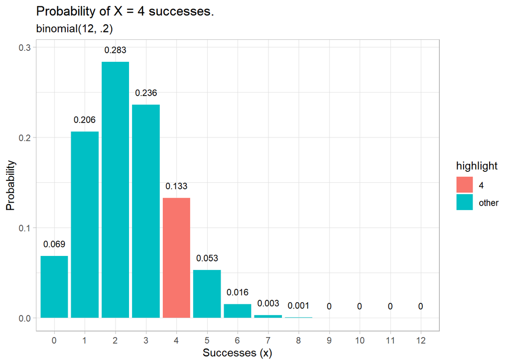

```r
df_binomial <- data.frame(
  success = 0:n_experiments,
  prob = dbinom(
    x = 0:n_experiments,
    size = n_experiments,
    prob = prob_success
  )
) %>%
  mutate(highlight = ifelse(success == n_success, as.character(n_success), "other"))

df_binomial %>%
  ggplot(mapping = aes(
    x = factor(success),
    y = prob,
    fill = highlight
  )) +
  geom_col() +
  geom_text(
    aes(label = round(prob, 3), y = prob + 0.01),
    position = position_dodge(0.9),
    size = 3,
    vjust = 0
  ) +
  labs(
    title = paste("Probability of X =", n_success, "successes."),
    subtitle = "binomial(12, .2)",
    x = "Successes (x)",
    y = "Probability"
  ) +
  theme_light()
```

#### Normal distribution:

The mean test score of a college entrance exam is 72, and the standard deviation is 15.2, assuming normality. What is the percentage of students scoring 84 or more in the exam?

```r
pnorm(q = 84, mean = 72, sd = 15.2, lower.tail = FALSE)
```

```
[1] 0.2149176
```

```r
dnorm(x = 84, mean = 72, sd = 15.2)
```

```
[1] 0.01921876
```

```r
qnorm(p = 0.5, mean = 72, sd = 15.2, lower.tail = TRUE)
```

```
[1] 72
```

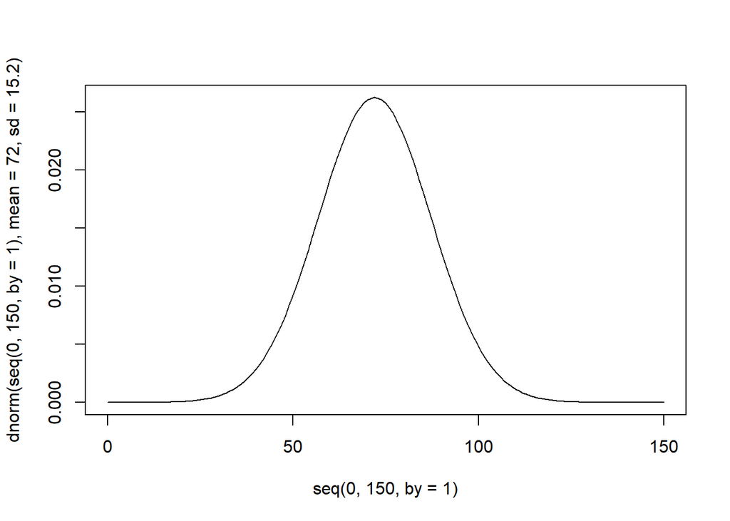

```r
plot(
  x = seq(0, 150, by = 1),
  y = dnorm(seq(0, 150, by = 1), mean = 72, sd = 15.2),
  type = 'l'
)
```

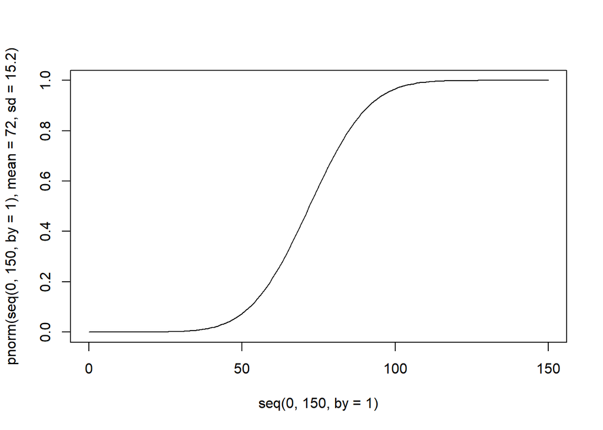

```r
plot(
  seq(0, 150, by = 1),
  pnorm(seq(0, 150, by = 1), mean = 72, sd = 15.2), type = 'l'
     )
```

Random numbers from the normal distribution:

```r
rnorm(n = 20, mean = 72, sd = 15.2)
```

```
 [1]  88.02341  66.58914  61.53039  99.37087  72.01389  54.93083  58.32165
 [8]  58.03418 107.98240  51.24697  53.96801  47.28654  78.70398  57.44978
[15]  72.06481  79.40276  68.34386  89.84749  61.19744  99.21519
```

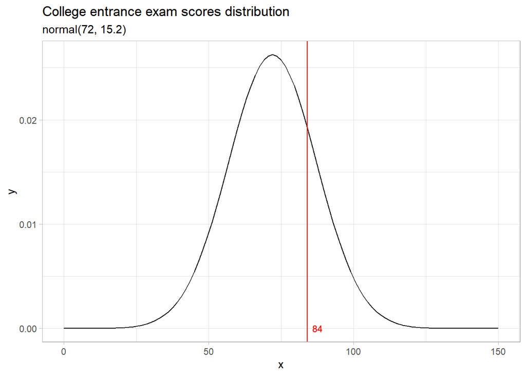

```r
df_normal <- data.frame(x = c(0, 150))

ggplot(data = df_normal,
       mapping = aes(x = x)) +
  stat_function(fun = dnorm, args = list(mean = 72, sd = 15.2)) +
  geom_vline(xintercept = 84, col = 'red') +
  labs(title = 'College entrance exam scores distribution',
       subtitle = 'normal(72, 15.2)') +
  geom_text(
    aes(label = '84', x = 84, y = 0),
    size = 3,
    hjust = -.5,
    col = 'red'
  ) +
  theme_light()
```

#### Poisson distribution:

The Poisson distribution is the probability distribution of independent event occurrences in an interval (mainly time) when we know the average ($\lambda$) of occurrences per interval.

If there are twelve cars crossing a bridge per minute on average, the probability of having seventeen cars crossing the bridge in a particular minute is:

```r
dpois(x = 17, lambda = 12)
```

```
[1] 0.03832471
```

The probability of having sixteen *or less* cars crossing the bridge in a minute is in the lower tail of the probability density function. This is:

```r
ppois(q = 16, lambda = 12, lower.tail = TRUE)
```

```
[1] 0.898709
```

### Simulating experiments

We can use R to simulate the outcome of experiments when we know the distribution of probabilities.

With `choose()` we can simulate combinations easily according to the binomial coefficient: $\binom{n}{k} = \frac{n!}{k!(n-k)!}$

```r
# How many football lineups can we choose with a squad of 25 players (for the sake of simplicity, consider any player can be goalkeeper)
choose(n = 25, k = 11)
```

```
[1] 4457400
```

```r
factorial(25) / (factorial(11) * factorial(25-11))
```

```
[1] 4457400
```

If we want to know which are the specific combinations, we can use the function `combn()`

```r
# Which are the possible combinations of the 5 first letters of the alphabet if we take 3 at a time?
combn(x = letters[1:5], m = 3)
```

```
     [,1] [,2] [,3] [,4] [,5] [,6] [,7] [,8] [,9] [,10]
[1,] "a"  "a"  "a"  "a"  "a"  "a"  "b"  "b"  "b"  "c"
[2,] "b"  "b"  "b"  "c"  "c"  "d"  "c"  "c"  "d"  "d"
[3,] "c"  "d"  "e"  "d"  "e"  "e"  "d"  "e"  "e"  "e"
```

```r
choose(n = 5, k = 3)
```

```
[1] 10
```

We can compute permutations as well (when the order of the elements matter), using the function `permutations()` from the package `gtools`:

```r
# Which are the possible permutations of the 5 first letters of the alphabet if we take 3 at a time?
permutations(n = 5, r = 3, v = letters[1:5], repeats.allowed = FALSE)
```

```
      [,1] [,2] [,3]
 [1,] "a"  "b"  "c"
 [2,] "a"  "b"  "d"
 [3,] "a"  "b"  "e"
 [4,] "a"  "c"  "b"
 [5,] "a"  "c"  "d"
 [6,] "a"  "c"  "e"
 [7,] "a"  "d"  "b"
 [8,] "a"  "d"  "c"
 [9,] "a"  "d"  "e"
[10,] "a"  "e"  "b"
[11,] "a"  "e"  "c"
[12,] "a"  "e"  "d"
[13,] "b"  "a"  "c"
[14,] "b"  "a"  "d"
```

[output cut: 46 more lines]

```r
nrow(permutations(n = 5, r = 3, v = letters[1:5], repeats.allowed = FALSE))
```

```
[1] 60
```

The function `sample()` allows us to get samples of data, according to specific probabilities:

```r
# Simulate 50 coin tosses when the coin is fair
sample(x = c('head', 'tail'), size = 50, replace = TRUE)
```

```
 [1] "tail" "head" "head" "tail" "head" "tail" "head" "tail" "tail" "head"
[11] "head" "tail" "tail" "head" "head" "head" "head" "tail" "tail" "tail"
[21] "tail" "tail" "head" "tail" "head" "tail" "tail" "tail" "tail" "head"
[31] "tail" "head" "head" "head" "tail" "tail" "head" "head" "tail" "head"
[41] "tail" "tail" "tail" "head" "head" "head" "tail" "head" "tail" "head"
```

```r
prop.table(table(sample(x = c('head', 'tail'), size = 50, replace = TRUE)))
```

```
head tail
0.48 0.52
```

```r
# Simulate 50 coin tosses when the coin is loaded
sample(x = c('head', 'tail'), size = 50, replace = TRUE)
```

```
 [1] "head" "head" "tail" "head" "head" "head" "tail" "head" "head" "tail"
[11] "head" "tail" "head" "tail" "tail" "head" "head" "tail" "tail" "head"
[21] "tail" "tail" "tail" "head" "head" "head" "head" "tail" "head" "head"
[31] "tail" "head" "head" "tail" "tail" "head" "tail" "head" "head" "tail"
[41] "tail" "head" "head" "tail" "head" "tail" "tail" "head" "head" "tail"
```

```r
prop.table(table(sample(x = c('head', 'tail'), size = 50, replace = TRUE, prob = c(0.25, 0.75))))
```

```
head tail
 0.2  0.8
```

With `replicate()`, we can repeat experiments to get probabilities. Imagine we want to know, in average, how many times must a 6-sided die be rolled until a number n turns up. With `sample()` we simulate rolls:

```r
sample(x = 1:6, size = 1)
```

```
[1] 4
```

And using while statement we can execute sample until the desired condition is met:

```r
# Roll dice until we get n
desired_number <- 6
x <- 0
while(x != desired_number) {
  x <- sample(x = 1:6, size = 1)
  print(x)
}
```

```
[1] 1
[1] 1
[1] 3
[1] 2
[1] 4
[1] 3
[1] 1
[1] 1
[1] 2
[1] 4
[1] 3
[1] 4
[1] 4
[1] 5
[1] 6
```

So now, we can pack the code inside a function:

```r
roll_dice <- function(desired_number) {
  # This function simulates the number of dice rolls to get a desired number
  i <- 0      ## A counter of rolls
  x <- 0
  while(x != desired_number) {
    x <- sample(x = 1:6, size = 1)
    i <- i + 1
  }
  return(i)
}

# The result of this function is the number of rolls to get a 6
roll_dice(desired_number = 6)
```

```
[1] 3
```

```r
# So, in average, after n experiments, we need y rolls to get desired number
mean(replicate(n = 1000, expr = roll_dice(desired_number = 6)))
```

```
[1] 6.191
```

### Correlation

Correlation is a measure of linear relationship between two variables.

```r
loan_data <- fread(
  file = "./DATA/loan_data.csv",
  header = TRUE,
  sep = ",",
  stringsAsFactors = FALSE,
  dec = "."
)
```

```r
cor(loan_data$annual_inc, loan_data$loan_amnt)
```

```
[1] 0.4035427
```

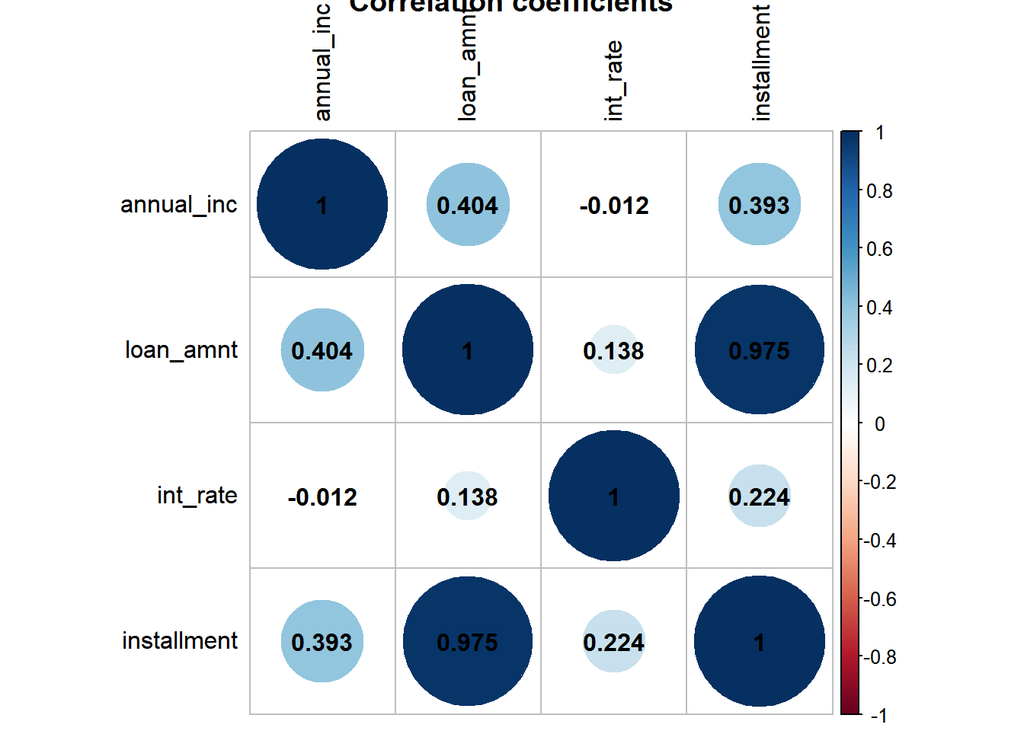

```r
loan_data %>%
  select(annual_inc, loan_amnt, int_rate, installment) %>%
  cor(use = 'complete.obs') %>%
  corrplot(
    title = 'Correlation coefficients',
    addCoef.col = TRUE,
    tl.col = 'black',
    number.digits = 3
  )
```

```r
loan_data$grade_num <- as.numeric(as.factor(loan_data$grade))

cor(loan_data[, c('grade_num', 'default')], use = "complete.obs")
```

```
          grade_num   default
grade_num 1.0000000 0.1523802
default   0.1523802 1.0000000
```

A different form of “correlation” used for binary variables: the AUC. Given a numerical variable X and a binary variable Y, AUC represents the probability of an instance Y = 1 having a higher value on X than and instance Y = 0. That is, if we order Y by X, the probability of placing a 1 before than a 0 It goes from 0.5 to 1, where 0.5 is that of a random order.

Simulated data:

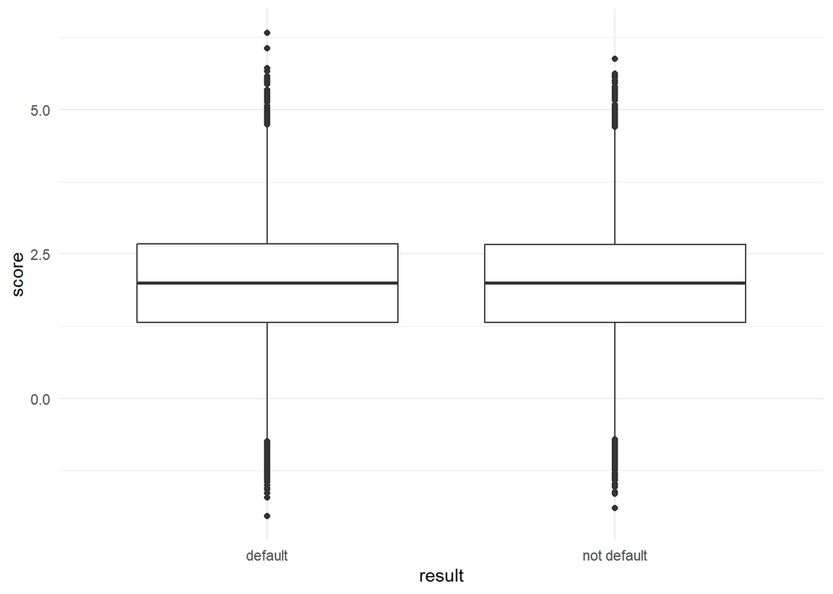

```r
n <- 30000
mean_default      <- 2
mean_not_default  <- 2
set.seed(42)

# Change the value of the mean of rnorm() in data frame default to explore different values of AUC

default <- data.frame(result = "default",
                      score = rnorm(n = n,
                                    mean = mean_default,
                                    sd = 1)
                      )

not_default <- data.frame(result = "not default",
                          score = rnorm(n = n,
                                        mean = mean_not_default,
                                        sd = 1)
                          )

data <- rbind(default, not_default)

ggplot(data, aes(result, score)) +
  geom_boxplot() +
  theme_minimal()
```

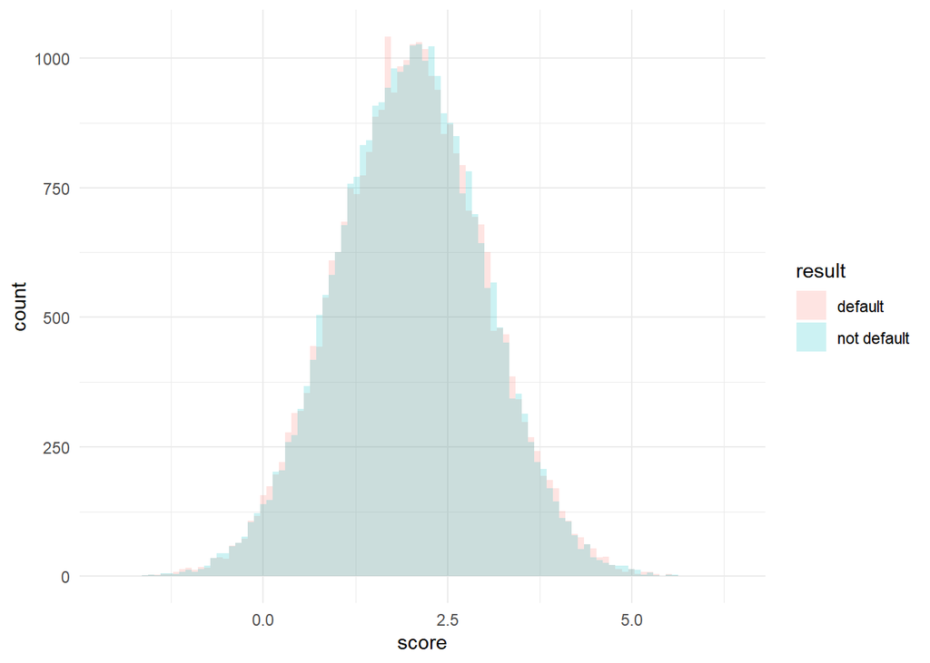

```r
ggplot(data, aes(score, fill = result)) +
  geom_histogram(position = "identity",
                 alpha = 0.2,
                 bins = 100) +
  theme_minimal()
```

AUC: It measures the probability that the scoring of a randomly chosen default is higher than that of a randomly chosen not_default.

```r
auc(data$result, data$score)
```

```
Area under the curve: 0.499
```

AUC from loan_data:

```r
auc(loan_data$default, loan_data$int_rate)
```

```
Area under the curve: 0.6418
```

### Estimation and error

```r
mean(loan_data$default)
```

```
[1] 0.09164506
```

```r
obs <- c(10, 50, 100, 500, 1000, 2000, 5000, 10000, nrow(loan_data))

result <- c()

for (i in obs) {
  x <- mean(sample(loan_data$default, size = i, replace = F))
  result <- append(result, x)
  print(paste(i, 'observations', '->', x))
}
```

```
[1] "10 observations -> 0"
[1] "50 observations -> 0.04"
[1] "100 observations -> 0.08"
[1] "500 observations -> 0.084"
[1] "1000 observations -> 0.099"
[1] "2000 observations -> 0.0825"
[1] "5000 observations -> 0.0842"
[1] "10000 observations -> 0.0906"
[1] "15811 observations -> 0.0916450572386313"
```

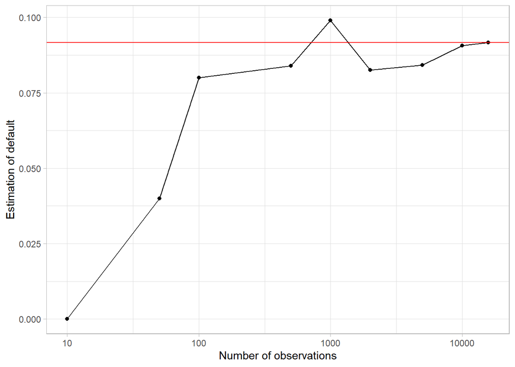

```r
ggplot(data = data.frame(obs,
                         result),
       aes(x = obs, y = result)) +
  geom_line() +
  geom_point() +
  geom_hline(yintercept = mean(loan_data$default), col = 'red') +
  scale_x_log10() +
  xlab(label = 'Number of observations') +
  ylab(label = 'Estimation of default') +
  theme_light()
```

The standard deviation / sqrt(N), where N is the number of observations, gives us an estimation of the error:

```r
errors <- c()

for (i in obs) {
  error <- sd(loan_data[1:i, default], na.rm = T) / sqrt(i)
  errors <- append(errors, error)
}

errors
```

```
[1] 0.133333333 0.042857143 0.031446604 0.013309632 0.009406619 0.006588908
[7] 0.004043570 0.002863393 0.002294650
```

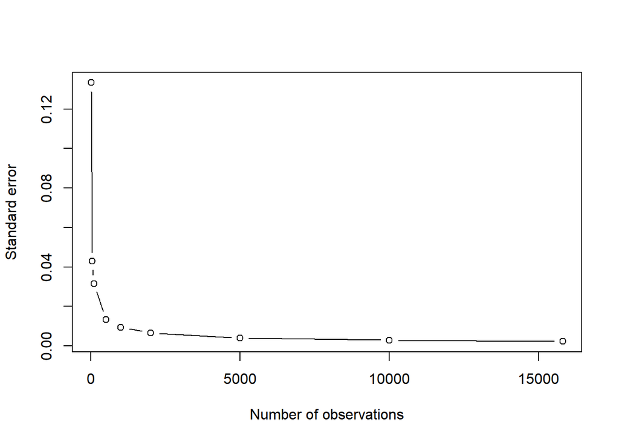

```r
plot(
  x = obs,
  y = errors,
  type = 'b',
  xlab = 'Number of observations',
  ylab = 'Standard error'
)
```

With the estimated value of the mean and its standard error, we can build a range of possible values for the “population” value named Confidence Interval The confidence interval represents the range of values for the mean that we could observe, with certain probability, in case we make another estimation of the mean with a new sample.

How likely would we observe values on that range? It depends upon the ” confidence level”. If we define a 95% Interval, then 95% of the times we estimate the mean with another sample we would observe values on the interval. That is why it is commonly said that, for example, “we are 95% sure that the mean will be between the 95-IC range”.

Values of the 90, 95 and 99 confidence level:

```r
qnorm(p = c(0.05, 0.95))
```

```
[1] -1.644854  1.644854
```

```r
qnorm(p = c(0.025, 0.975))
```

```
[1] -1.959964  1.959964
```

```r
qnorm(p = c(0.005, 0.995))
```

```
[1] -2.575829  2.575829
```

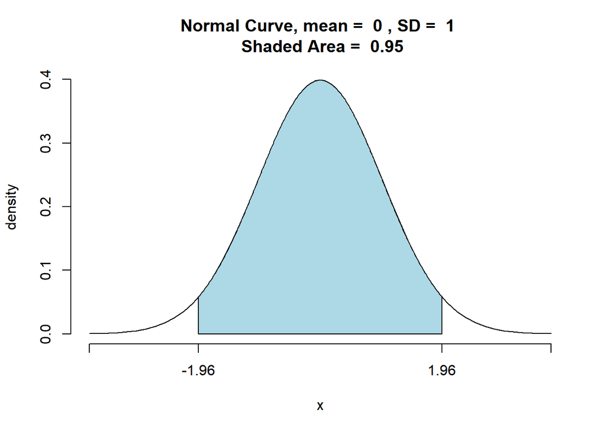

```
[1] 0.9500042
```

```r
pnormGC(
  round(qnorm(p = c(0.025, 0.975)), digits = 2),
  region = "between",
  mean = 0,
  sd = 1,
  graph = TRUE
)
```

95-Interval of Confidence for the mean with 1000 observations:

```r
n <- 1000

obs <- sample(size = n, x = loan_data$default, replace = F)

prop <- mean(obs)

error <- sd(obs) / sqrt(length(obs))

conf_int <-
  c(
    Inferior = prop - qnorm(p = 0.975) * error,
    Superior = prop + qnorm(p = 0.975) * error
  )

conf_int
```

```
  Inferior   Superior
0.07864751 0.11535249
```

Little demonstration:

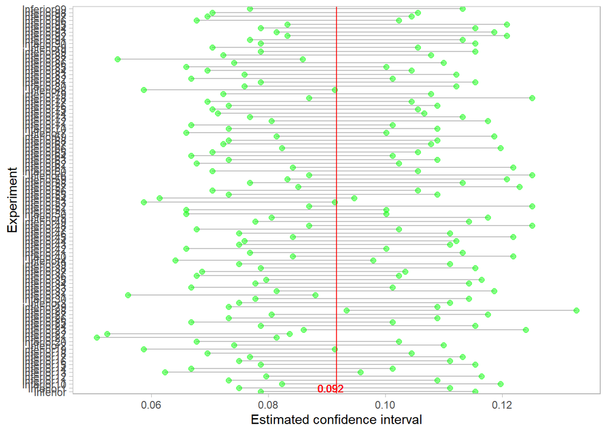

```r
df_conf_int <- data.frame()

for (i in 1:100) {
  n <- 1000
  obs <- sample(size = n,
                x = loan_data$default,
                replace = F)
  prop <- mean(obs)
  error <- sd(obs) / sqrt(length(obs))
  conf_int_temp <-
    c(
      Inferior = prop - qnorm(p = 0.975) * error,
      Superior = prop + qnorm(p = 0.975) * error
    )
  df_temp <- data.frame(inf = conf_int_temp[1],
                        sup = conf_int_temp[2])
  df_conf_int <- rbind(df_conf_int, df_temp)
}

df_conf_int <- df_conf_int %>%
  rownames_to_column(var = 'experiment')

ggplot(df_conf_int) +
  geom_segment(aes(
    x = experiment,
    xend = experiment,
    y = inf,
    yend = sup
  ), color = "grey") +
  geom_point(
    aes(x = experiment, y = inf),
    color = 'green',
    size = 2,
    alpha = 0.5
  ) +
  geom_point(
    aes(x = experiment, y = sup),
    color = 'green',
    size = 2,
    alpha = 0.5
  ) +
  geom_hline(yintercept = mean(loan_data$default), col = 'red') +
  geom_text(aes(
    x = 'Inferior1',
    y = mean(loan_data$default) - 0.001,
    label = round(mean(loan_data$default), 3)
  ),
  col = 'red',
  size = 3) +
  coord_flip() +
  xlab('Experiment') +
  ylab('Estimated confidence interval') +
  theme_light() +
  theme(panel.grid = element_blank(),
        panel.grid.major = element_blank()
  )
```

### Hypothesis testing

#### t-test

Let’s see if there’s genuine differences in the default rate amongst grade D and G:

$H_{0}$ $->$ There is no difference between both groups, the observed difference in the mean is due to chance.

$H_{1}$ $->$ There is a statistically significant difference between both groups.

```r
gD <- loan_data$default[loan_data$grade == 'D']

gG <- loan_data$default[loan_data$grade == 'G']

mean_diff <- mean(gD) - mean(gG)
mean_diff
```

```
[1] -0.07843335
```

```r
t_test <- t.test(gD, gG, alternative = 'two.sided')
t_test
```

```
    Welch Two Sample t-test

data:  gD and gG
t = -2.3489, df = 178.45, p-value = 0.01992
alternative hypothesis: true difference in means is not equal to 0
95 percent confidence interval:
 -0.14432543 -0.01254126
sample estimates:
mean of x mean of y
0.1424256 0.2208589
```

#### ANOVA test

Comparing delivery times:

```r
food <- fread('./DATA/food.csv')

food %>% group_by(driver) %>% summarise(
  mean = mean(deliv.time),
  sd = sd(deliv.time),
  len = length(deliv.time)
)
```

```
# A tibble: 5 × 4
  driver  mean    sd   len
  <chr>  <dbl> <dbl> <int>
1 Alison  9.75  1.98     8
2 Anna   11.1   2.70     8
3 Grant  13.6   1.92     8
4 Joe    10.1   1.89     8
5 Kyle   11.2   1.75     8
```

```r
food %>% group_by(driver) %>%
  summarise(across(deliv.time, list(
    mean = mean,
    sd = sd,
    len = length
  )))
```

```
# A tibble: 5 × 4
  driver deliv.time_mean deliv.time_sd deliv.time_len
  <chr>            <dbl>         <dbl>          <int>
1 Alison            9.75          1.98              8
2 Anna             11.1           2.70              8
3 Grant            13.6           1.92              8
4 Joe              10.1           1.89              8
5 Kyle             11.2           1.75              8
```

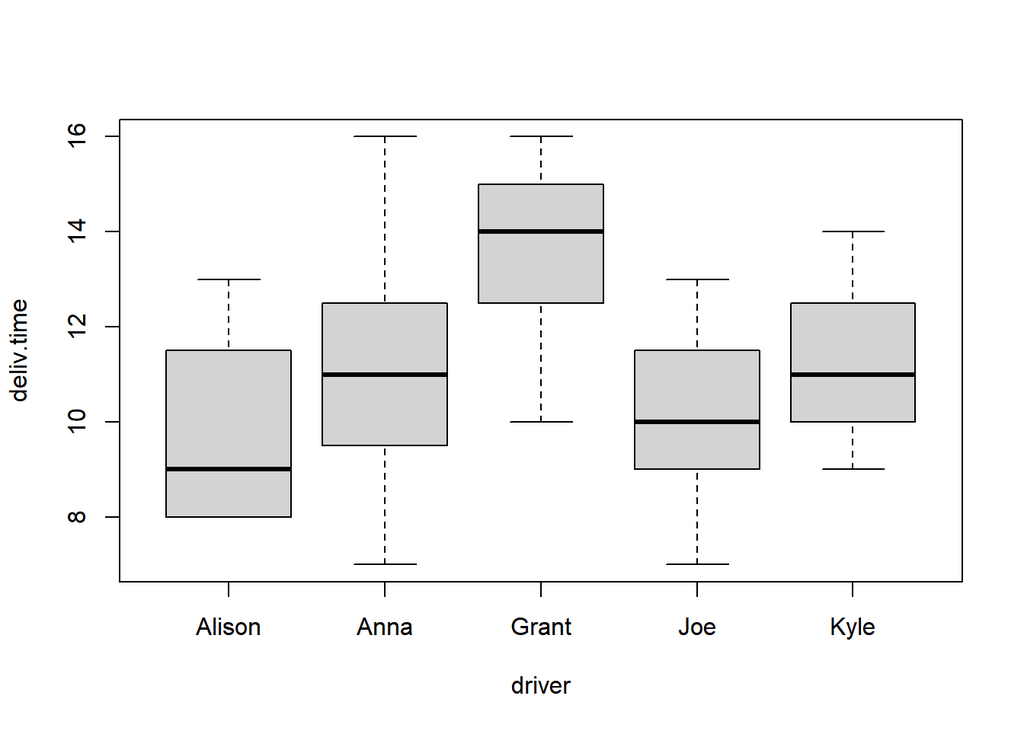

```r
boxplot(deliv.time ~ driver, data = food)
```

```r
anova_test <- aov(deliv.time ~ driver, data = food)
anova_test
```

```
Call:
   aov(formula = deliv.time ~ driver, data = food)

Terms:
                 driver Residuals
Sum of Squares   73.150   150.625
Deg. of Freedom       4        35

Residual standard error: 2.074505
Estimated effects may be unbalanced
```

#### Tukey’s HSD test (pairwise comparison between drivers)

```r
TukeyHSD(anova_test)
```

```
  Tukey multiple comparisons of means
    95% family-wise confidence level

Fit: aov(formula = deliv.time ~ driver, data = food)

$driver
               diff        lwr        upr     p adj
Anna-Alison   1.375 -1.6071637  4.3571637 0.6774553
Grant-Alison  3.875  0.8928363  6.8571637 0.0056319
Joe-Alison    0.375 -2.6071637  3.3571637 0.9961752
Kyle-Alison   1.500 -1.4821637  4.4821637 0.6029992
Grant-Anna    2.500 -0.4821637  5.4821637 0.1364255
Joe-Anna     -1.000 -3.9821637  1.9821637 0.8692540
Kyle-Anna     0.125 -2.8571637  3.1071637 0.9999499
Joe-Grant    -3.500 -6.4821637 -0.5178363 0.0146889
Kyle-Grant   -2.375 -5.3571637  0.6071637 0.1723577
Kyle-Joe      1.125 -1.8571637  4.1071637 0.8131646
```

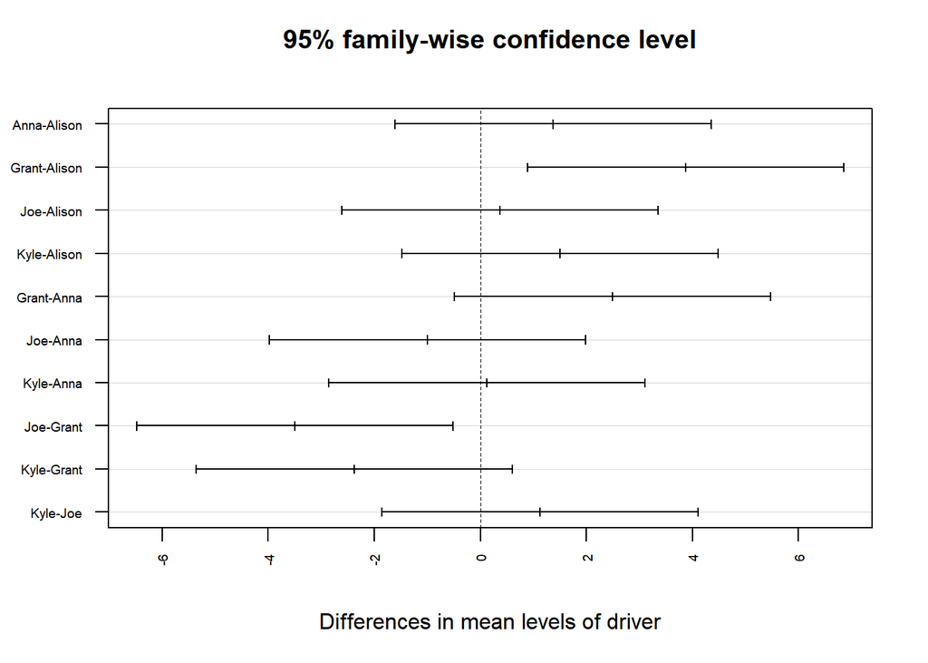

```r
plot(TukeyHSD(anova_test), cex.axis = .6, las = 2)
```

#### Chi-square test

Is preferred packaging related to income level?

```r
plastic <- c(low = 47, middle = 51, upper = 33)
eco <- c(low = 43, middle = 63, upper = 76)

table <- rbind(plastic, eco)
table
```

```
        low middle upper
plastic  47     51    33
eco      43     63    76
```

```r
apply(table, 1, sum)
```

```
plastic     eco
    131     182
```

```r
apply(table, 2, sum)
```

```
   low middle  upper
    90    114    109
```

```r
sum(table)
```

```
[1] 313
```

```r
chisq.test(table)
```

```
    Pearson's Chi-squared test

data:  table
X-squared = 10.37, df = 2, p-value = 0.005601
```

### Exercise

1. On average, how many times must a 6-sided die be rolled until you get a desired_number n times in a row?

```r
roll_dice_n <- function(n) {
  i <- 0
  x <- 0
  while(x != 6) {
    x <- mean(sample(x = 1:6, size = n, replace = TRUE))
    i <- i + 1
  }
  return(i)
}

roll_dice_n(6)
```

```
[1] 10020
```

```r
mean(replicate(n = 1000, roll_dice_n(3)))
```

```
[1] 212.621
```

## Footnotes

[^1]: If you need to catch up with basic concepts of statistics and probability, take a look at [OpenIntro](https://www.openintro.org/book/os/).